Name: **Rahul Ranjan**  
Roll No: **20CS8016**

# **CSS453 Lab 5** - Laplace Transform

```python
import sympy as sp
sp.init_printing(use_latex=True)

def L(f):
  return sp.laplace_transform(f,t,s, noconds=True)

def invL(F):
  return sp.inverse_laplace_transform(F,s,t)

t,s = sp.symbols('t,s')
a = sp.symbols('a', real=True, positive=True)

def r(t):
  return t * sp.Heaviside(t)
```

#### **Question 1**

1. Find the Laplace transform of the following:  
   a. $\scriptsize 𝑦 = 𝑡^2$  
   b. $\scriptsize 𝑦 = 𝑒^{−𝑎𝑡} + 𝑒^{−3𝑎𝑡}$  
   c. $\scriptsize 𝑦 = 𝑒^{2𝑡}sin(2𝑡)$  
   d. $\scriptsize 𝑦 = 𝑒^{3𝑡} + cos(6𝑡) − 𝑒^{−3𝑡}cos(6𝑡)$  
   e. $\scriptsize 𝑦 = 𝑢(𝑡 − 2) + 2𝑢(𝑡 − 3) − 2𝑟(𝑡 − 2)$

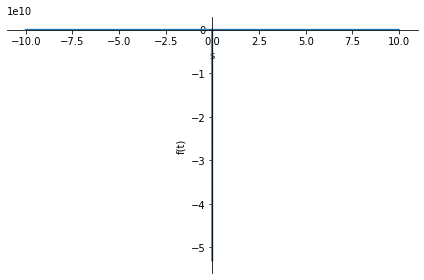

$\displaystyle \frac{2}{s^{3}}$

```python
# 1.a.
y = t**2
f = L(y)
sp.plot(f, ylabel='f(t)')
f
```

```python
# 1.b.
y = sp.exp(-a*t) + sp.exp(-3*a*t)
L(y)
```

$\displaystyle \frac{2 \left(2 a + s\right)}{\left(a + s\right) \left(3 a + s\right)}$

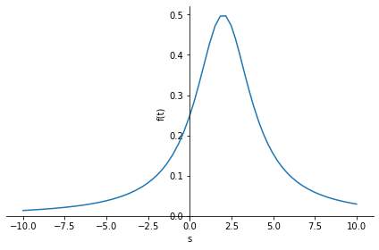

$\displaystyle \frac{2}{\left(s - 2\right)^{2} + 4}$

```python
# 1.c.
y = sp.exp(2*t)*sp.sin(2*t)
f = L(y)
sp.plot(f, ylabel='f(t)')
f
```

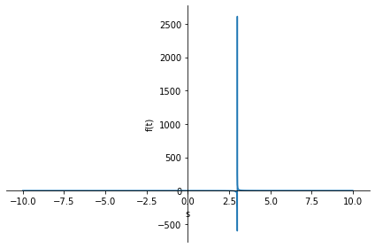

$\displaystyle \frac{s}{36 \left(\frac{s^{2}}{36} + 1\right)} + \frac{1}{3 \left(\frac{s}{3} - 1\right)} - \frac{1}{\left(1 + \frac{36}{\left(s + 3\right)^{2}}\right) \left(s + 3\right)}$

```python
# 1.d.
y = sp.exp(3*t) + sp.cos(6*t) - (sp.exp(-3*t)*sp.cos(6*t))
f = L(y)
sp.plot(f, ylabel='f(t)')
f
```

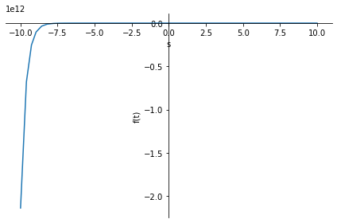

$\displaystyle \frac{\left(s e^{s} + 2 s - 2 e^{s}\right) e^{- 3 s}}{s^{2}}$

```python
# 1.e.
y = sp.Heaviside(t-2) + 2*sp.Heaviside(t-3) - 2*r(t-2)
f = L(y)
sp.plot(f, ylabel='f(t)')
f
```

#### **Question 2**

Consider the two functions $\scriptsize 𝑓(𝑡) = 𝑢(𝑡)𝑢(3 − 𝑡)$ and $\scriptsize 𝑔(𝑡) = 𝑢(𝑡) − 𝑢(𝑡 − 3)$.  
(a) Are the two functions identical?  
(b) Show that 𝐿[𝑓(𝑡)] = 𝐿[𝑔(𝑡)]

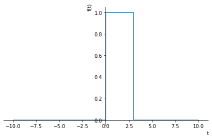

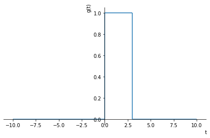

```
<sympy.plotting.plot.Plot at 0x7fdf8b35c390>
```

```python
f = sp.Heaviside(t) * sp.Heaviside(3 - t)
g = sp.Heaviside(t) - sp.Heaviside(t - 3)

# 2.a.
sp.plot(f, ylabel='f(t)')
sp.plot(g, ylabel='g(t)')
```

```python
# 2.b.
print(L(f))
print(L(g))
print(L(f) == L(g))
```

```
1/s - exp(-3*s)/s
1/s - exp(-3*s)/s
True
```

#### **Question 3**

Using the definition, find 𝐿[𝑓(𝑡)], if it exists. If the Laplace transform exists then find the domain of 𝐹(𝑠). $$ f(𝑡) = \begin{cases} 0 & \quad \text{0 ≤ 𝑡 < 1}\\ 𝑡 − 1 & \quad \text{1 ≤ 𝑡 < 2}\\ 0 & \quad \text{2 ≤ 𝑡} \end{cases} $$

```python
f = t-1
F = sp.integrate(f*sp.exp(-s*t), (t, 1, 2))
F
```

$\displaystyle \begin{cases} \frac{\left(- s - 1\right) e^{- 2 s}}{s^{2}} + \frac{e^{- s}}{s^{2}} & \text{for}\: s > -\infty \wedge s < \infty \wedge s \neq 0 \\\frac{1}{2} & \text{otherwise} \end{cases}$

#### **Question 4**

Find the inverse Laplace transform of the following:  
(a) $\scriptsize 𝐹(𝑠) = \dfrac{1}{𝑠}$  
(b) $\scriptsize 𝐹(𝑠) = \dfrac{10}{𝑠^2+25} + \dfrac{4}{𝑠−3}$  
(c) $\scriptsize 𝐹(𝑠) = \dfrac{𝑒^{−3𝑠}(2𝑠+7)}{𝑠^2+16}$  
(d) $\scriptsize 𝐹(𝑠) = \dfrac{𝑠^2+5𝑠−3}{(𝑠^2+16)(𝑠−2)}$

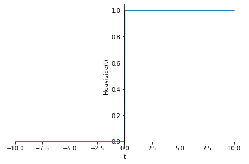

$\displaystyle \theta\left(t\right)$

```python
# 4.a.
F = 1/s
f = invL(F)
sp.plot(f, ylabel=f)
f
```

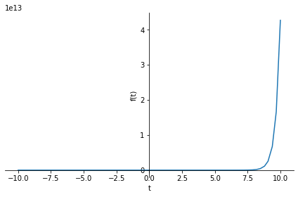

$\displaystyle 2 \left(2 e^{3 t} + \sin{\left(5 t \right)}\right) \theta\left(t\right)$

```python
# 4.b.
F = (10/(s**2 + 25))+(4/(s-3))
f = invL(F)
sp.plot(f)
f
```

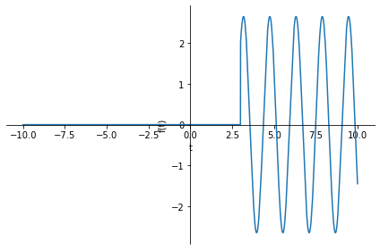

$\displaystyle \frac{\left(8 \sin{\left(12 \right)} \sin{\left(4 t \right)} + 7 \sin{\left(4 t \right)} \cos{\left(12 \right)} - 7 \sin{\left(12 \right)} \cos{\left(4 t \right)} + 8 \cos{\left(12 \right)} \cos{\left(4 t \right)}\right) \theta\left(t - 3\right)}{4}$

```python
# 4.c.
F = (sp.exp(-3*s)*(2*s + 7))/(s**2 + 16)
f = invL(F)
sp.plot(f)
f
```

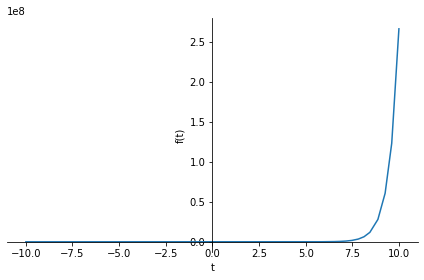

$\displaystyle \frac{\left(22 e^{2 t} + 59 \sin{\left(4 t \right)} + 18 \cos{\left(4 t \right)}\right) \theta\left(t\right)}{40}$

```python
# 4.d.
F = (s**2 + 5*s - 3)/((s**2 + 16)*(s-2))
f = invL(F)
sp.plot(f)
f
```

#### **Question 5**

The graph of 𝑓(𝑡) is given below. Represent 𝑓(𝑡) as a combination of Heaviside step functions calculate the Laplace transform of 𝑓(𝑡)

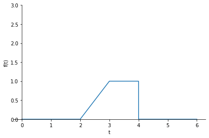

$\displaystyle \frac{\left(- 2 s e^{4 s} - s + e^{4 s} + e^{2 s} - e^{s}\right) e^{- 4 s}}{s^{2}}$

```python
f = r(t-2)*sp.Heaviside(3-t) + sp.Heaviside(t-3) - sp.Heaviside(t-4)
sp.plot(f,(t,0,6),ylim=(0,3))
L(f)
```

#### **Question 6**

Solve the initial value problem using Laplace transform  
(a) $\scriptsize 𝑦' + 2𝑦 = 4𝑡, 𝑦(0) = 3$  
(b) $\scriptsize 𝑦'' + 3𝑦' + 2𝑦 = 6𝑒^{−𝑡}, 𝑦(0) = 1, 𝑦'(0) = 2$  
(c) $\scriptsize 𝑦' + 4𝑦 = 𝑔(𝑡), 𝑦(0) = 2$, where $\scriptsize 𝑔(𝑡) = 12$ if $\scriptsize(1 < 𝑡 < 3)$ else 0

```python
y = sp.Function('y')(t)
y_ = sp.Derivative(y,t)     #  y_ == y'
y__ = sp.Derivative(y_,t)   # y__ == y''
```

```python
# 6.a.
f = y_ + 2*y - 4*t
L(f)
```

$\displaystyle 2 \mathcal{L}_{t}\left[y{\left(t \right)}\right]\left(s\right) + \mathcal{L}_{t}\left[\frac{d}{d t} y{\left(t \right)}\right]\left(s\right) - \frac{4}{s^{2}}$

```python
# 6.b.
f = y__ + 3*y_ + 2*y - 6*sp.exp(-t)
L(f)
```

$\displaystyle 2 \mathcal{L}_{t}\left[y{\left(t \right)}\right]\left(s\right) + 3 \mathcal{L}_{t}\left[\frac{d}{d t} y{\left(t \right)}\right]\left(s\right) + \mathcal{L}_{t}\left[\frac{d^{2}}{d t^{2}} y{\left(t \right)}\right]\left(s\right) - \frac{6}{s + 1}$

```python
# 6.c.
g = sp.Function('g')(t)
f = y_ + 4*y - g
L(f)
```

$\displaystyle - \mathcal{L}_{t}\left[g{\left(t \right)}\right]\left(s\right) + 4 \mathcal{L}_{t}\left[y{\left(t \right)}\right]\left(s\right) + \mathcal{L}_{t}\left[\frac{d}{d t} y{\left(t \right)}\right]\left(s\right)$

#### **Question 7**

Verify that multiplication in s domain is equivalent to Convolution in time domain

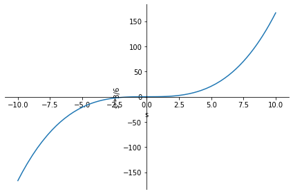

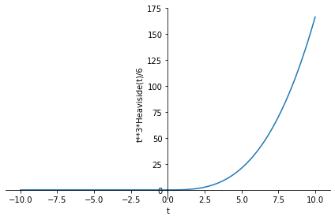

$\displaystyle \left( \frac{s^{3}}{6}, \ \frac{t^{3} \theta\left(t\right)}{6}\right)$

```python
f1 = t
f2 = s-t
F1 = sp.integrate(f1*f2, (t, 0, s))
F2 = invL(L(f1)*L(f1))
sp.plot(F1, ylabel=F1)
sp.plot(F2, ylabel=F2)
F1, F2
```